# Introduction to Bayesian

Hui Lin

2017-09-08

# Outside view

> *Likelihood function: In statistics, a likelihood function is a function of parameters of a statistical model given data. Likelihood functions play a key role in statistical inference, especially methods of estimating a parameter from a set of statistics. In informal contexts, “likelihood” is often used as a synonym for “probability”. In statistics, a distinction is made depending on the roles of outcomes vs. parameters. Probability is used before data are available to describe possible future outcomes given a fixed value for the parameter. Likelihood is used after data are available to describe a function of a parameter for given outcome. [Wikipedia]*

# Outside view

- Data have distributions
- Parameters do not
- Distinguish *parameters* and *statistics*
- Likelihood is not a probability distribution
- Imaginary *population*
- Bayes is sampling theory + priors
- Priors are uniquely subjective

# Conceptual friction

- Thinking data must look like likelihood function
- Degrees of freedom
- “Sampling” as source of all uncertainty
- Defining random effects via sampling design
- Neglect of data uncertainty

# Bayesian data analysis

- Contrast with frequentist view
  - Probability is just limiting frequency
  - Uncertainty arises from sampling variation
- Bayesian probability much more general
  - Probability is in the small world
  - Coins are not random, but our ignorance makes them so

# Another path

- Claim: Bayes easier and more powerful when understood from the inside
- Problem: Many insider views

# Small and Large Worlds

[figure not shown]

- **Small world**: the world under the model’s assumptions. Bayesian models are optimal, in the small world
- **Larger world**: the real world. No guarantee of optimality for any kind of model
- Have to worry about both

# Garden of Forking Data

- The future:
  - Full of branching paths
  - Each choice closes some
- The data:
  - Many possible events
  - Each observation eliminates some

# Garden of Forking Data

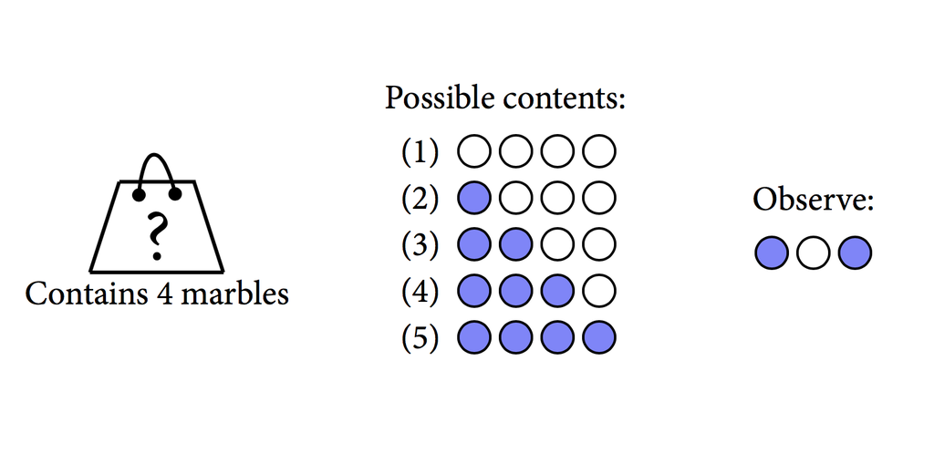

# Garden of Forking Data

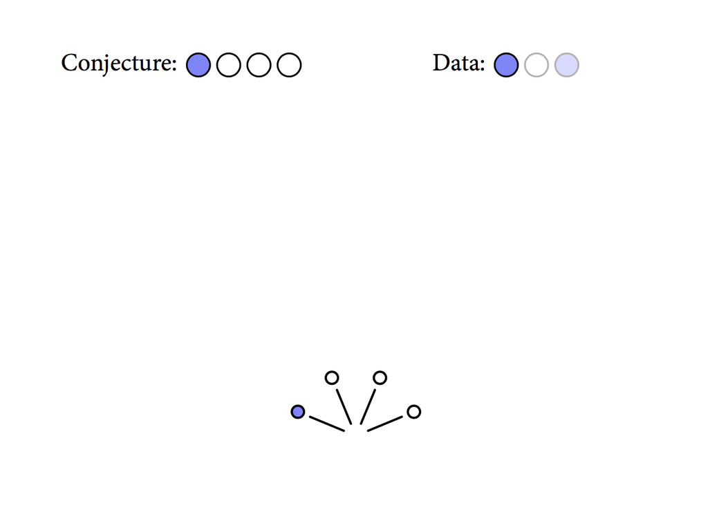

# Garden of Forking Data

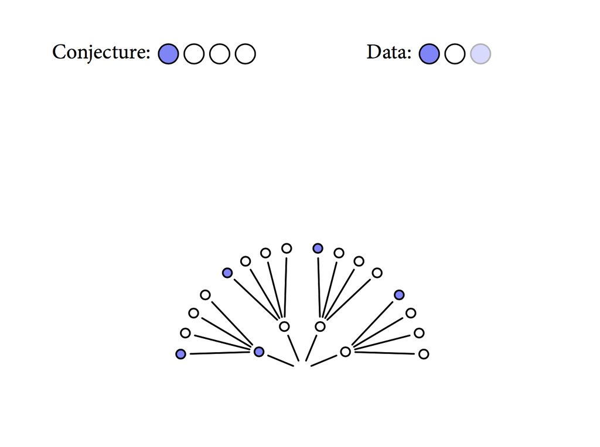

# Garden of Forking Data

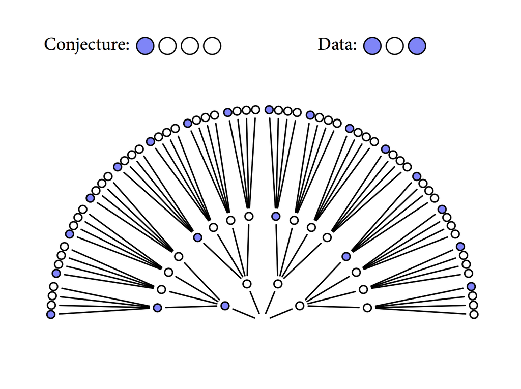

# Garden of Forking Data

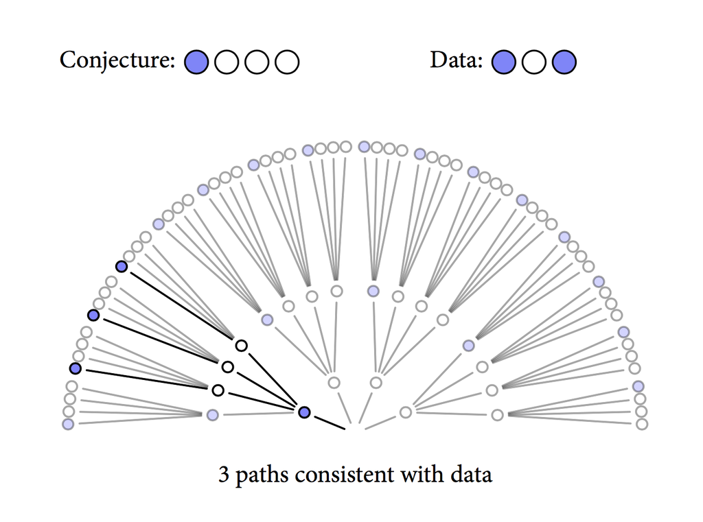

# Garden of Forking Data

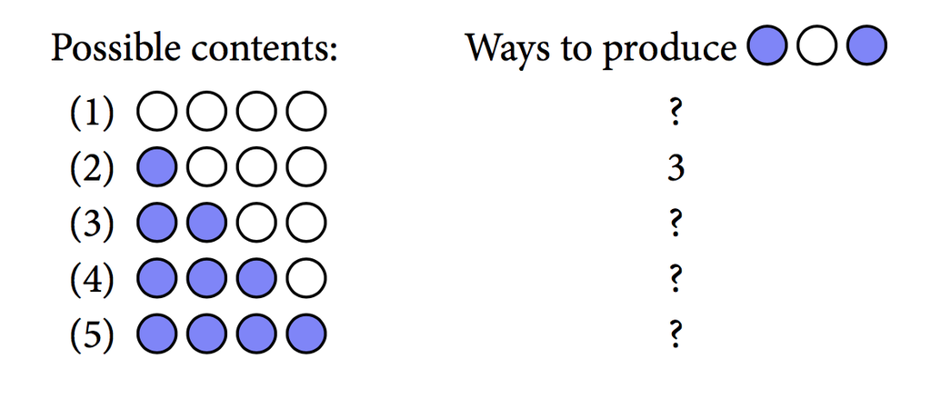

# Garden of Forking Data

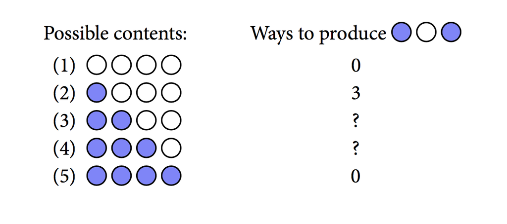

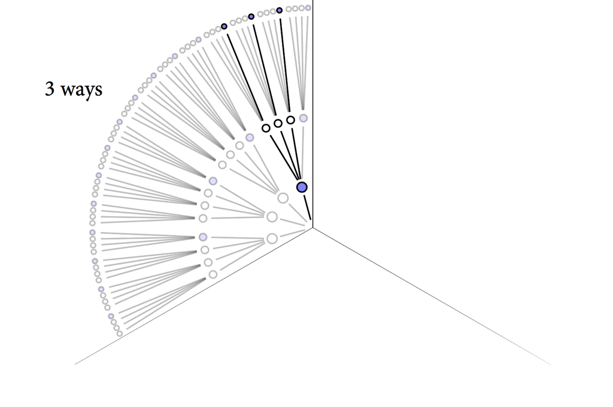

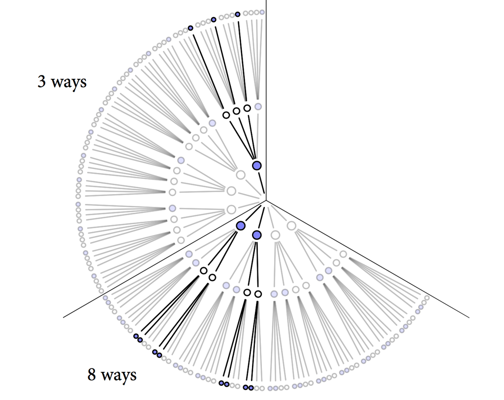

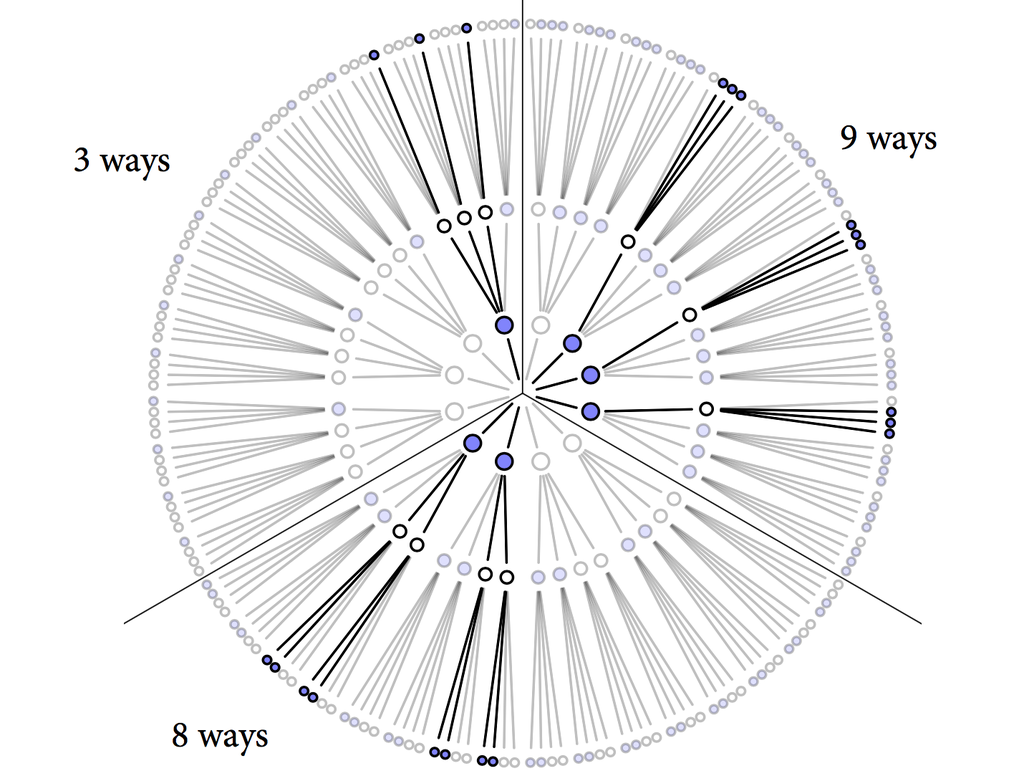

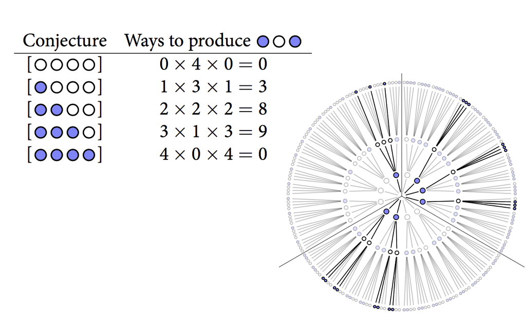